# Python Data Analysis Library

OpenTechSchool Workshop - [Hugo Herter](http://www.hugoherter.com) - August 2014

[figure not shown]

# Description

Pandas is a Python library providing high-performance, easy-to-use data structures and data analysis tools.

The library is oriented towards *DataFrames*, table-like data structures that can be manipulated by a collection of methods:

- sort, merge, join, filter, group by, reshape & pivots
- read/write Excell, CSV, SQL databases, JSON
- view as tables, plot graphs

If you are familiar with R, think of [R Data Frames](https://stat.ethz.ch/R-manual/R-devel/library/base/html/data.frame.html) ported to Python.

Under the hood, Pandas is based on [NumPy](http://www.numpy.org/), a powerful library for numerical computing in Python - you will encounter it a few times in this workshop.

# When did people register to this event

The usecase we will be investigating is the following:

```
When did people register for this event ? Up to how many per day ? What hour during the day ?
```

To achieve this, we will load the RSVPs information about this event from Meetup's API, load it into Pandas and manipulate it in order to answer the question above.

# First steps

From Python data structures to Pandas

```python
# Import and configure NumPy, Matplotlib and other useful math tools for running within the Notebook
%pylab inline
```

```python
# Load Pandas as any Python library:
import pandas
```

Get your hands on a simple DataFrame

```python
dataframe = pandas.DataFrame(range(0, 50, 10))
dataframe
```

|  | 0 |
| --- | --- |
| 0 | 0 |
| 1 | 10 |
| 2 | 20 |
| 3 | 30 |
| 4 | 40 |

You can plot this DataFrame by calling it's `plot()` method.

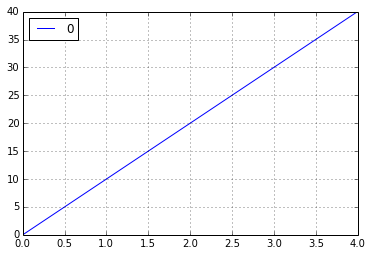

```python
dataframe.plot()
```

By pressing TAB after typing `dataframe.`, the notebook will show you other methods you can use on this DataFrame. Don't hesitate to experiment.

# Meetup's data

For this exercise, we will have a look at [this event](http://www.meetup.com/OpenTechSchool-Brussels/events/194806872/)'s data on Meetup.

### First

Grab your API authentication key: https://secure.meetup.com/meetup_api/key/

### Second

Load the required libraries

- `import requests` for HTTP requests
- API key
- Event ID from the URL: `194806872`
- API urls
  - subscriptions: https://api.meetup.com/2/rsvps/
  - event's description: https://api.meetup.com/2/event/{event_id}

### Third

Load the data and parse it.

URL -> JSON -> DataFrame

```python
import requests  # load HTTP requests
from __future__ import print_function  # use Python 3 syntax for print(...)

api_key = '72d84e1c4c2a50321268137412e73'
event_id = '194806872'

rsvps_url = "https://api.meetup.com/2/rsvps/"
event_url = "https://api.meetup.com/2/event/" + event_id

print("URLs:")
print(rsvps_url)
print(event_url)
```

```
URLs:
https://api.meetup.com/2/rsvps/
https://api.meetup.com/2/event/194806872
```

# Fetching data from the Meetup API

First, load the data from the URL `rsvps_url`. You need to pass it two parameters: your API key and the identifier of the event.

```python
rsvps_dict = requests.get(rsvps_url, params={'key': api_key, 'event_id': event_id}).json()
```

You can then print the first result to see how it looks like. Here, we only print the first valye of the sub-element 'results' because the whole content is quite long, but you can experiment with it and try printing all of it or other subsets.

```python
rsvps_dict['results'][0]
```

```
{u'created': 1408919587000,
 u'event': {u'event_url': u'http://www.meetup.com/OpenTechSchool-Brussels/events/194806872/',
  u'id': u'194806872',
  u'name': u'Learn Data analysis with IPython Notebook and Pandas',
  u'time': 1409072400000},
 u'group': {u'group_lat': 50.83000183105469,
  u'group_lon': 4.329999923706055,
  u'id': 9462812,
  u'join_mode': u'open',
  u'urlname': u'OpenTechSchool-Brussels'},
 u'guests': 0,
 u'member': {u'member_id': 162880392, u'name': u'Yannick Yemo'},
 u'member_photo': {u'highres_link': u'http://photos2.meetupstatic.com/photos/member/6/8/6/2/highres_220706722.jpeg',
  u'photo_id': 220706722,
  u'photo_link': u'http://photos4.meetupstatic.com/photos/member/6/8/6/2/member_220706722.jpeg',
  u'thumb_link': u'http://photos2.meetupstatic.com/photos/member/6/8/6/2/thumb_220706722.jpeg'},
 u'mtime': 1408919587000,
 u'response': u'yes',
 u'rsvp_id': 1411704412,
 u'venue': {u'address_1': u'Franklin Rooseveltlaan 50, Brussels',
  u'city': u'Brussels',
  u'country': u'be',
  u'id': 21985282,
  u'lat': 50.81473,
  u'lon': 4.381928,
  u'name': u'ULB Building K, third floor, room K.3.201 (Campus Solbosch)',
  u'repinned': True}}
```

# Transformation into a Pandas DataFrame

Pandas can load data from many different formats. In this case, our data are structured as a list of dictionnaries, which can easily be translated into a table.

Note that the source document is hierarchical with a depth greater than one for some fields. Once converted to a DataFrame, the value for these fields will keep its hierarchical structure as a Python dictionnary (display is cropped in the table below).

```python
results = rsvps_dict['results']

rsvps_raw = pandas.DataFrame(results)
rsvps_raw.head()  # only prints the top rows of the table
```

|  | created | event | group | guests | member | member_photo | mtime | response | rsvp_id | venue |
| --- | --- | --- | --- | --- | --- | --- | --- | --- | --- | --- |
| 0 | 1408919587000 | {u'event_url': u'http://www.meetup.com/OpenTec... | {u'urlname': u'OpenTechSchool-Brussels', u'gro... | 0 | {u'name': u'Yannick Yemo', u'member_id': 16288... | {u'thumb_link': u'http://photos2.meetupstatic.... | 1408919587000 | yes | 1411704412 | {u'city': u'Brussels', u'name': u'ULB Building... |
| 1 | 1408633578000 | {u'event_url': u'http://www.meetup.com/OpenTec... | {u'urlname': u'OpenTechSchool-Brussels', u'gro... | 0 | {u'name': u'Yann', u'member_id': 140547792} | {u'thumb_link': u'http://photos3.meetupstatic.... | 1408633578000 | yes | 1407439252 | {u'city': u'Brussels', u'name': u'ULB Building... |
| 2 | 1408636360000 | {u'event_url': u'http://www.meetup.com/OpenTec... | {u'urlname': u'OpenTechSchool-Brussels', u'gro... | 0 | {u'name': u'Robert Johnston', u'member_id': 14... | NaN | 1408636360000 | yes | 1407497352 | {u'city': u'Brussels', u'name': u'ULB Building... |
| 3 | 1407686959000 | {u'event_url': u'http://www.meetup.com/OpenTec... | {u'urlname': u'OpenTechSchool-Brussels', u'gro... | 0 | {u'name': u'Dylan Soubien', u'member_id': 1383... | {u'thumb_link': u'http://photos3.meetupstatic.... | 1407686959000 | no | 1391751912 | {u'city': u'Brussels', u'name': u'ULB Building... |
| 4 | 1405346392000 | {u'event_url': u'http://www.meetup.com/OpenTec... | {u'urlname': u'OpenTechSchool-Brussels', u'gro... | 0 | {u'name': u'Ludo', u'member_id': 137883082} | NaN | 1405346392000 | yes | 1354372332 | {u'city': u'Brussels', u'name': u'ULB Building... |

# Index by 'created' field

```python
# Index the raw dataframe by RSVP creation date:
# - convers the 'created' field to a DateTime - Pandas wants microseconds
rsvps_raw.index = pandas.to_datetime(rsvps_raw['created'] * 1000000)
```

As you can see, the first columns of your DataFrame looks different: it has been set as the index of the table:

```python
rsvps_raw.head(3)
```

| created | created | event | group | guests | member | member_photo | mtime | response | rsvp_id | venue |
| --- | --- | --- | --- | --- | --- | --- | --- | --- | --- | --- |
| 2014-08-24 22:33:07 | 1408919587000 | {u'event_url': u'http://www.meetup.com/OpenTec... | {u'urlname': u'OpenTechSchool-Brussels', u'gro... | 0 | {u'name': u'Yannick Yemo', u'member_id': 16288... | {u'thumb_link': u'http://photos2.meetupstatic.... | 1408919587000 | yes | 1411704412 | {u'city': u'Brussels', u'name': u'ULB Building... |
| 2014-08-21 15:06:18 | 1408633578000 | {u'event_url': u'http://www.meetup.com/OpenTec... | {u'urlname': u'OpenTechSchool-Brussels', u'gro... | 0 | {u'name': u'Yann', u'member_id': 140547792} | {u'thumb_link': u'http://photos3.meetupstatic.... | 1408633578000 | yes | 1407439252 | {u'city': u'Brussels', u'name': u'ULB Building... |
| 2014-08-21 15:52:40 | 1408636360000 | {u'event_url': u'http://www.meetup.com/OpenTec... | {u'urlname': u'OpenTechSchool-Brussels', u'gro... | 0 | {u'name': u'Robert Johnston', u'member_id': 14... | NaN | 1408636360000 | yes | 1407497352 | {u'city': u'Brussels', u'name': u'ULB Building... |

# Clean DataFrame

The DataFrame you have just created contains both information we are not interested in and information structured in sub-dictionnaries.

You will therefore create a new DataFrame and copy only the information relevant for our task into it.

```python
# Create a new 'clean' DataFrame:
rsvps = pandas.DataFrame(rsvps_raw['response'])

# Here is a function that will return the given key from a dictionnary if it exists,
# and else return None. You will use it to extract information from dictionnary fields.
def get_or_nan(dic, key):
    try: return dic.get(key)
    except AttributeError: return None

rsvps['name'] = rsvps_raw['member'].map(lambda x: x.get('name'))
rsvps['thumb'] = rsvps_raw['member_photo'].map(lambda x: get_or_nan(x, 'thumb_link'))
rsvps['photo'] = rsvps_raw['member_photo'].map(lambda x: get_or_nan(x, 'photo_link'))

rsvps.head(5)
```

| created | response | name | thumb | photo |
| --- | --- | --- | --- | --- |
| 2014-08-24 22:33:07 | yes | Yannick Yemo | http://photos2.meetupstatic.com/photos/member/... | http://photos4.meetupstatic.com/photos/member/... |
| 2014-08-21 15:06:18 | yes | Yann | http://photos3.meetupstatic.com/photos/member/... | http://photos1.meetupstatic.com/photos/member/... |
| 2014-08-21 15:52:40 | yes | Robert Johnston | None | None |
| 2014-08-10 16:09:19 | no | Dylan Soubien | http://photos3.meetupstatic.com/photos/member/... | http://photos3.meetupstatic.com/photos/member/... |
| 2014-07-14 13:59:52 | yes | Ludo | None | None |

## Grouping data

Pandas contains a lot of shortcuts and handful properties. For example, the date or the hour of a *Datetime* column can be extracted easily in the form of `dataframe.column.date` or `dataframe.column.hour`.

The method `groupby(field name)` on a DataFrame allows for grouping it's content by a certain column for further processing. In this case, you will want to group it by day and then aggregate the length of each group to get the number of registrations for each day. (This will only show registrations for dates with at least one registration).

```python
# Create a new column containing only the date (without the time)
rsvps['day'] = rsvps.index.date
rsvps_per_day = rsvps.groupby('day').agg(len)
rsvps_per_day
```

| day | response | name | thumb | photo |
| --- | --- | --- | --- | --- |
| 2014-07-14 | 8 | 8 | 8 | 8 |
| 2014-07-15 | 4 | 4 | 4 | 4 |
| 2014-07-16 | 3 | 3 | 3 | 3 |
| 2014-07-17 | 1 | 1 | 1 | 1 |
| 2014-07-18 | 1 | 1 | 1 | 1 |
| 2014-07-21 | 1 | 1 | 1 | 1 |
| 2014-07-23 | 1 | 1 | 1 | 1 |
| 2014-07-26 | 1 | 1 | 1 | 1 |
| 2014-07-28 | 1 | 1 | 1 | 1 |
| 2014-07-30 | 1 | 1 | 1 | 1 |
| 2014-08-01 | 1 | 1 | 1 | 1 |
| 2014-08-02 | 1 | 1 | 1 | 1 |
| 2014-08-03 | 1 | 1 | 1 | 1 |
| 2014-08-04 | 1 | 1 | 1 | 1 |
| 2014-08-06 | 1 | 1 | 1 | 1 |
| 2014-08-09 | 1 | 1 | 1 | 1 |
| 2014-08-10 | 2 | 2 | 2 | 2 |
| 2014-08-11 | 2 | 2 | 2 | 2 |
| 2014-08-12 | 1 | 1 | 1 | 1 |
| 2014-08-17 | 2 | 2 | 2 | 2 |
| 2014-08-18 | 2 | 2 | 2 | 2 |
| 2014-08-19 | 1 | 1 | 1 | 1 |
| 2014-08-20 | 5 | 5 | 5 | 5 |
| 2014-08-21 | 4 | 4 | 4 | 4 |
| 2014-08-22 | 1 | 1 | 1 | 1 |
| 2014-08-23 | 1 | 1 | 1 | 1 |
| 2014-08-24 | 2 | 2 | 2 | 2 |
| 2014-08-25 | 3 | 3 | 3 | 3 |

Now that you got your data, you may want to visualize it as a graph using the `plot()` method. Specifying the marker allows to see more precisely the data points.

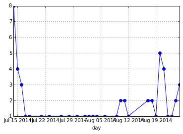

```python
rsvps_per_day['response'].plot(marker='o')
```

# Grouping by hour and going further.

You can also look at the hour of the day at which people registered for this event by grouping by hour.

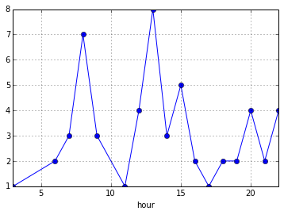

```python
rsvps['hour'] = rsvps.index.hour
rsvps_per_hour = rsvps.groupby('hour').agg(len)
rsvps_per_hour['response'].plot(marker='o')
```

From here, you can have a look at the photo of the people who did register at a given hour. In this example, I will show you how to look for people who did register at 13h (after 13h and before 14h), and who have a profile photo.

`rsvps.thumb.notnull()` will give you a boolean matrix you can use to filter out people with no profile photo.

*Reminder*: `.head()` is used to only print the first rows of the result.

```python
rsvps.thumb.notnull().head()
```

```
created
2014-08-24 22:33:07     True
2014-08-21 15:06:18     True
2014-08-21 15:52:40    False
2014-08-10 16:09:19     True
2014-07-14 13:59:52    False
Name: thumb, dtype: bool
```

In a similar way, `rsvps.hour==13` will give you a boolean matrix you can use to filter people who registeted at 13h.

```python
(rsvps.hour == 13).head()
```

```
created
2014-08-24 22:33:07    False
2014-08-21 15:06:18    False
2014-08-21 15:52:40    False
2014-08-10 16:09:19    False
2014-07-14 13:59:52     True
Name: hour, dtype: bool
```

You can combine both these filters as follows, and you should only get RSVPs between 13h and 14h with a profile picture.

```python
rsvps[rsvps.thumb.notnull()][rsvps.hour==13]
```

| created | response | name | thumb | photo | day | hour |
| --- | --- | --- | --- | --- | --- | --- |
| 2014-08-20 13:03:10 | yes | Satblip | http://photos3.meetupstatic.com/photos/member/... | http://photos3.meetupstatic.com/photos/member/... | 2014-08-20 | 13 |
| 2014-07-14 13:05:24 | no | Steve | http://photos2.meetupstatic.com/photos/member/... | http://photos2.meetupstatic.com/photos/member/... | 2014-07-14 | 13 |
| 2014-07-14 13:46:05 | yes | Antonio Rebordao | http://photos1.meetupstatic.com/photos/member/... | http://photos3.meetupstatic.com/photos/member/... | 2014-07-14 | 13 |
| 2014-07-28 13:59:23 | no | Rosalind Lester | http://photos3.meetupstatic.com/photos/member/... | http://photos3.meetupstatic.com/photos/member/... | 2014-07-28 | 13 |
| 2014-07-14 13:42:39 | yes | Matteo Gagliolo | http://photos1.meetupstatic.com/photos/member/... | http://photos3.meetupstatic.com/photos/member/... | 2014-07-14 | 13 |
| 2014-08-20 13:04:16 | yes | Augustin | http://photos2.meetupstatic.com/photos/member/... | http://photos4.meetupstatic.com/photos/member/... | 2014-08-20 | 13 |

Finally, you can plot the member's photos:

```python
from IPython.display import Image

for i in rsvps[rsvps.thumb.notnull()][rsvps.hour==13].thumb:
    display(Image(i))
```

[output not shown]

How would you search for the photo for registrations during night time ?

# Geographical data

Finally, you will have a look at some geographical data to see how well they can be manipulated in the notebook.

In this chapter, you will download the list of venues of past OpenTechSchool Brussels events from Meetup, filter empty values and display them on a map of Brussels.

The Map section will be handled with folium, a Python library to control the famous [Leaflet](http://leafletjs.com/) JavaScript library for Interactive Maps.

```python
OTS_venues_url = "https://api.meetup.com/2/venues"
```

```python
venues_dict = requests.get(OTS_venues_url, params={'key': api_key, 'group_urlname': "OpenTechSchool-Brussels", 'status': 'past'}).json()
```

```python
venues_dict['results'][0]
```

```
{u'address_1': u'Bessenveldstraat 19',
 u'city': u'Diegem',
 u'country': u'be',
 u'distance': 0,
 u'id': 13589072,
 u'lat': 50.882275,
 u'lon': 4.436641,
 u'name': u'Capgemini Belgium',
 u'rating': 4,
 u'rating_count': 1}
```

```python
venues = pandas.DataFrame(venues_dict['results'])
venues
```

|  | address_1 | city | country | distance | id | lat | lon | name | phone | rating | rating_count |
| --- | --- | --- | --- | --- | --- | --- | --- | --- | --- | --- | --- |
| 0 | Bessenveldstraat 19 | Diegem | be | 0 | 13589072 | 50.882275 | 4.436641 | Capgemini Belgium | NaN | 4.00 | 1 |
| 1 | Koolmijnenkaai 30-34 | Brussels | be | 0 | 1277210 | 50.854667 | 4.342152 | FoAM vzw | NaN | 5.00 | 3 |
| 2 | Steenweg op Etterbeek 180 | Brussels | be | 0 | 1318152 | 50.838128 | 4.380773 | Google Belgium | +32 477 482870 | 4.60 | 25 |
| 3 | Rue du Moulin 40 \| Molenstraat 40 | Brussels | be | 0 | 14691632 | 50.850338 | 4.351710 | Hackerspace Brussels | NaN | 4.67 | 21 |
| 4 | 30-34 Quai des Charbonnages | Brussels | be | 0 | 18557642 | 50.854759 | 4.342060 | iMal | NaN | 5.00 | 2 |
| 5 | Rue Sans Souci 131, 1050 Ixelles | Brussels | be | 0 | 21499202 | 50.832249 | 4.372640 | Ixelles Library Sans Soucie | NaN | 4.67 | 3 |
| 6 | Chaussée de Louvain 242 | Brussels | be | 0 | 19428452 | 50.850121 | 4.380240 | Labokube | NaN | 4.50 | 4 |
| 7 | Avenue Franklin Roosevelt 50 | Brussels | be | 0 | 18625132 | 0.000000 | 0.000000 | Room K.3.401, Building K, Third floor, ULB Cam... | NaN | 4.00 | 2 |
| 8 | Avenue Franklin Roosevelt 50 | Brussels | be | 0 | 19526042 | 50.811722 | 4.381080 | Room K.4.401, Building K, Fourth Floor, ULB Ca... | NaN | 4.25 | 4 |
| 9 | Franklin Rooseveltlaan 50, Brussels | Brussels | be | 0 | 21985282 | 50.811722 | 4.381080 | ULB Building K, third floor, room K.3.201 (Cam... | NaN | 0.00 | 0 |
| 10 | Franklin Rooseveltlaan 50 | Brussels | be | 0 | 17352662 | 0.000000 | 0.000000 | ULB Campus Solbosch Batiment K, third floor, r... | NaN | 4.00 | 2 |

# Venues on a Map

First, you will need to import `folium`. Make sure you have installed it, else use `pip install folium`.

```python
import folium
```

The following function will allow you to include the maps directly into IPython Notebook.

```python
from IPython.display import HTML
def inline_map(map):
    "Embeds the HTML source of the map directly into the IPython notebook."
    map._build_map()
    return HTML('<iframe srcdoc="{srcdoc}" style="width: 100%; height: 510px; border: none"></iframe>'.format(srcdoc=map.HTML.replace('"', '&quot;')))
```

Finally, show a map of Brussels with a marker for each venue from the DataFrame:

```python
Brussels = [50.850338, 4.351710]
map = folium.Map(location=Brussels, zoom_start=12, tiles='Stamen Toner')

for index, row in venues[venues.lat!=0].iterrows():
    map.simple_marker([row.lat, row.lon], popup=str(row['name']))

inline_map(map)
```

[interactive chart not shown]

# That's it !

I hope you got the taste of IPython Notebook and Pandas.

You can discover more on the web via the [nbviewer](http://nbviewer.ipython.org/) website, for example:

- How to make [XKCD plots](http://nbviewer.ipython.org/url/jakevdp.github.com/downloads/notebooks/XKCD_plots.ipynb)
- [Mining Social Websites](http://nbviewer.ipython.org/github/ptwobrussell/Mining-the-Social-Web-2nd-Edition/tree/master/ipynb/)
- ...

You can also use the Notebook with the languages Ruby and Julia.

[figure not shown]